# Lab 06 - Permutational CIs and the Bootstrap

### Solution

#### Point 1

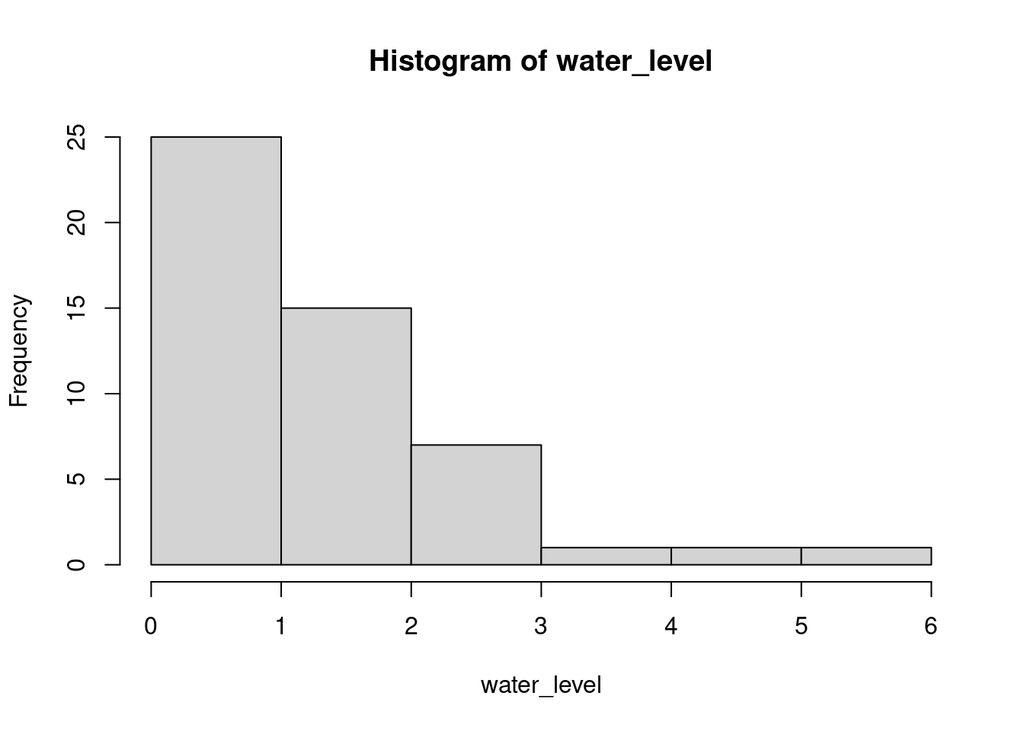

```r
load('./data/water_level_data/water_level.rda')

hist(water_level)
```

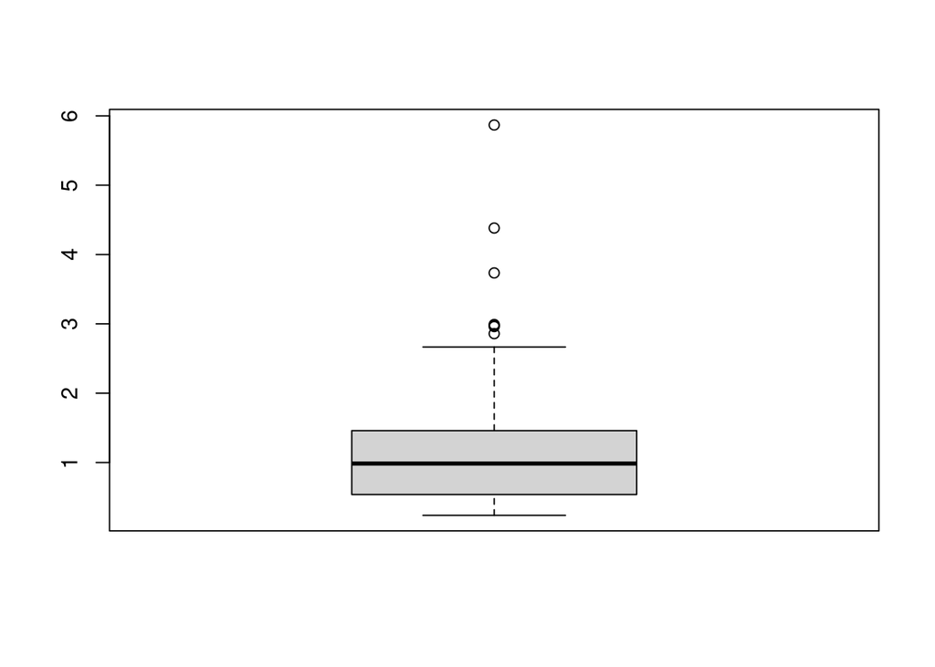

```r
boxplot(water_level)
```

We don’t know how a sample quantile is distributed… which means that to achieve what is asked in the exam I need to use bootstrapping!

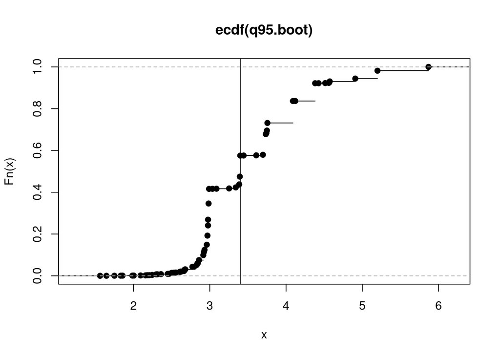

```r
B <- 10000
water.obs=water_level

q95.obs=quantile(water.obs,0.95)
q95.boot = numeric(B)
for(b in 1:B)
{
  water.b <- sample(water.obs, replace = T)
  q95.boot[b] = quantile(water.b,0.95)
}

plot(ecdf(q95.boot))
abline(v = q95.obs) #we can observe that it's quite skewed...
```

Let’s so compute the bias and the variance of the estimator

```r
var=var(q95.boot)
bias=mean(q95.boot)-q95.obs
RMSE=sqrt(var+bias^2)
var
```

```
## [1] 0.5072697
```

```r
bias
```

```
##       95%
## 0.1518097
```

```r
RMSE
```

```
##       95%
## 0.7282279
```

And for the confidence interval, let’s use the classic reverse percentiles

```r
alpha <- 0.05

right.quantile <- quantile(q95.boot, 1 - alpha/2)
left.quantile  <- quantile(q95.boot, alpha/2)

CI.RP <- c(q95.obs - (right.quantile - q95.obs), q95.obs, q95.obs - (left.quantile - q95.obs))
CI.RP
```

```
##      95%      95%      95%
## 1.599950 3.399583 4.133357
```

#### Point 2

To solve the second part, I need to understand that I can use a parametric bootstrap, and fit a lognormal to my data. How to fit the parameters of a lognormal distribution? do I need to do something weird? nope!

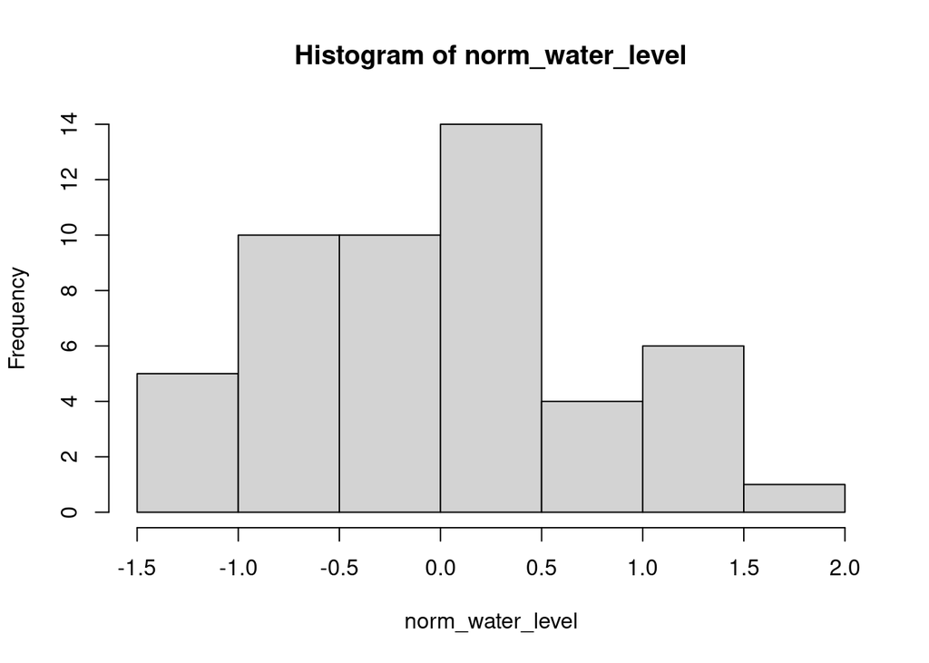

```r
norm_water_level=log(water_level)
hist(norm_water_level)
```

```r
shapiro.test(norm_water_level)
```

```
##
##  Shapiro-Wilk normality test
##
## data:  norm_water_level
## W = 0.97866, p-value = 0.4969
```

```r
mean=mean(norm_water_level)
sd=sqrt(var(norm_water_level))
n=length(norm_water_level)
```

Let’s set our parametric bootstrap procedure

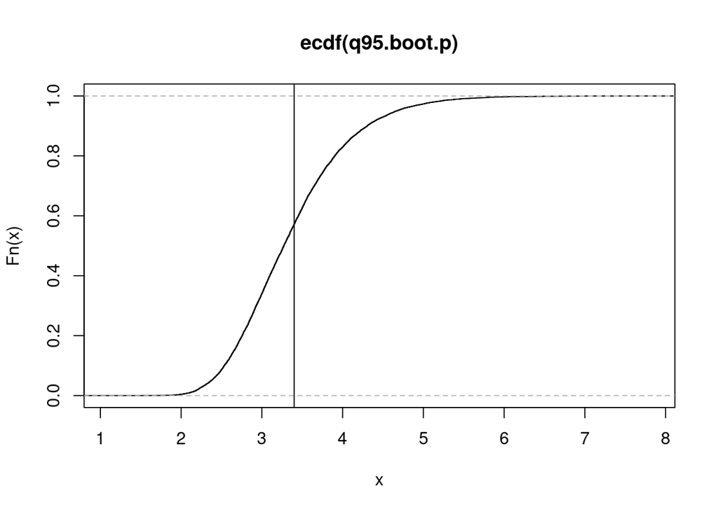

```r
q95.boot.p = numeric(B)

for(b in 1:B)
{
  water.b <- exp(rnorm(n,mean,sd))
  q95.boot.p[b] = quantile(water.b,0.95)
}

plot(ecdf(q95.boot.p))
abline(v = q95.obs)
```

And compute everything I need

```r
var.p=var(q95.boot.p)
bias.p=mean(q95.boot.p)-q95.obs
RMSE.p=sqrt(var.p+bias.p^2)

var=var(q95.boot)
bias=mean(q95.boot)-q95.obs
RMSE=sqrt(var+bias^2)

data.frame("Non Parametric"=c(var,bias,RMSE),"Parametric"=c(var.p,bias.p,RMSE.p))
```

| Non.Parametric | Parametric |
| --- | --- |
| 0.5072697 | 0.51037305 |
| 0.1518097 | -0.03887034 |
| 0.7282279 | 0.71546066 |

The parametric version is then slightly better than the nonparametric one…

```r
alpha <- 0.05

right.quantile <- quantile(q95.boot.p, 1 - alpha/2)
left.quantile  <- quantile(q95.boot.p, alpha/2)

CI.RP.p <- c(q95.obs - (right.quantile - q95.obs), q95.obs, q95.obs - (left.quantile - q95.obs))
CI.RP.p
```

```
##      95%      95%      95%
## 1.772790 3.399583 4.566484
```

## Exercise 5

The chief coach of the Pila-Aosta ski club has tasked you to select who, among its three top-class athletes in alpine skiing, can successfully compete also in ski-cross races, which have been recently “promoted” to an alpine discipline from its former “freestyle” status. One of the key areas in ski-cross is the moment when the athlete “jumps” in the track: this, differently from alpine skiing, happens after the blow of a whistle. For this reason, fast reaction times can make the difference between losing and winning. You’re so given the data about 100 “start” trials for the three athletes, stored in “parallel_gate.rda” The chief coach is asking if:

1. Are there any differences among the athletes? (see if you can use a parametric approach, if not, use a permutational one)
2. From a preliminary visual analysis, athlete 3 seems the best: how can you assess this, knowing what you discovered in 1.?
3. The coach is also asking you an idea of the “consistency” of athlete 3 out of the gate: provide him with a confidence interval for the mean of his reaction time (use a permutational approach).

### Solution

Load the data and have a look at it

```r
load('./data/parallel_gate_data/parallel_gate.rda')
head(chrono)
```

|  | reaction_time | athlete |
| --- | --- | --- |
| 1 | 2.3109997 | 1 |
| 2 | 2.2880683 | 1 |
| 3 | 1.6137042 | 1 |
| 4 | 0.8816244 | 1 |
| 5 | 1.9886475 | 1 |
| 6 | 1.5348088 | 1 |

let’s render the data usable for analysis, namely let’s convert the athlete in a factor, and let’s observe the data

```r
chrono$athlete=factor(chrono$athlete)
summary(chrono)
```

```
##  reaction_time    athlete
##  Min.   :0.1691   1:100
##  1st Qu.:0.9751   2:100
##  Median :1.5398   3:100
##  Mean   :1.5237
##  3rd Qu.:2.0319
##  Max.   :2.9766
```

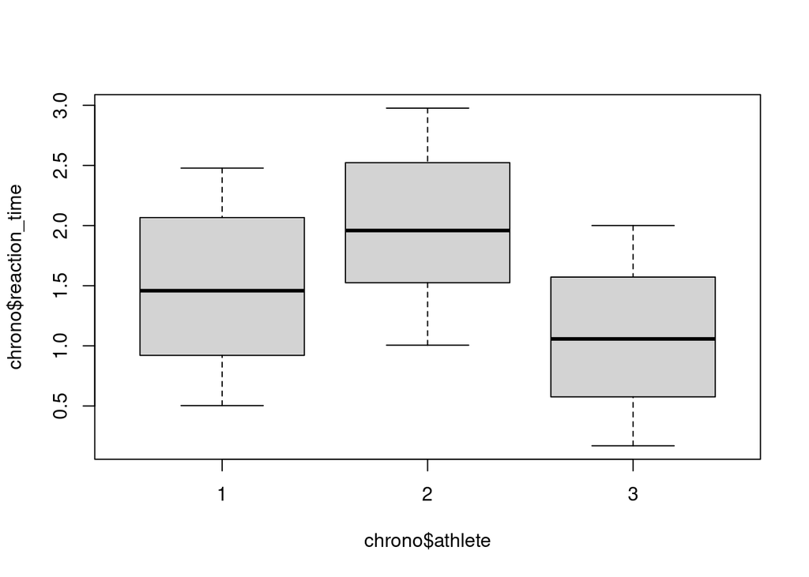

```r
attach(chrono)
boxplot(chrono$reaction_time ~ chrono$athlete)
```

Athlete 3 seems better than the others. Let’s assess if I can use a classic ANOVA

```r
model_norm=aov(reaction_time ~ athlete)
summary(model_norm)
```

```
##              Df Sum Sq Mean Sq F value Pr(>F)
## athlete       2   45.9   22.95   67.47 <2e-16 ***
## Residuals   297  101.0    0.34
## ---
## Signif. codes:  0 '***' 0.001 '**' 0.01 '*' 0.05 '.' 0.1 ' ' 1
```

```r
shapiro.test(model_norm$residuals)
```

```
##
##  Shapiro-Wilk normality test
##
## data:  model_norm$residuals
## W = 0.94391, p-value = 2.888e-09
```

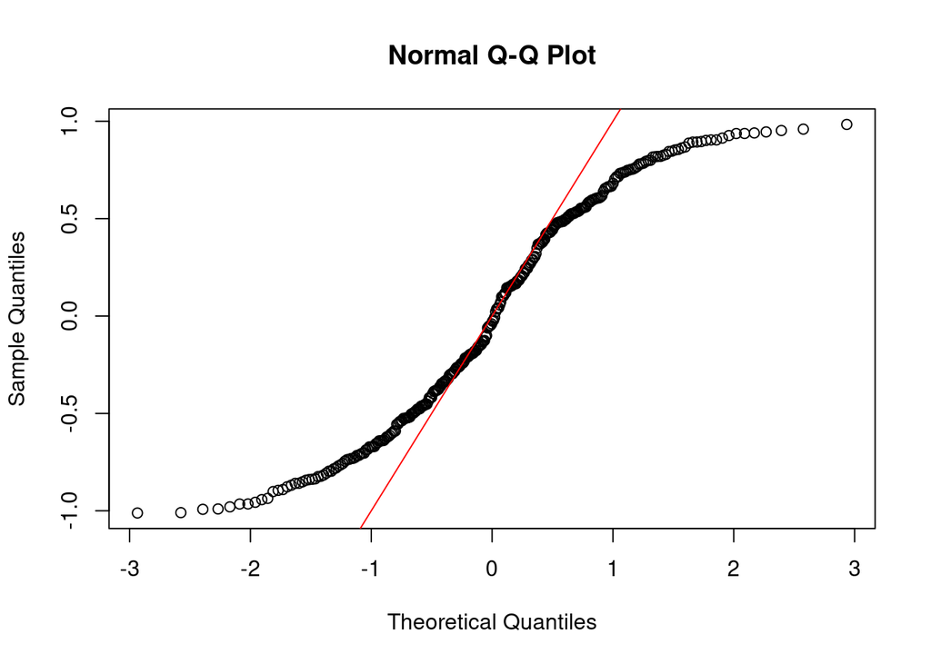

```r
qqnorm(model_norm$residuals)
abline(a=0,b=1,col='red')
```

Normality is not verified, let’s use permutational anova then

```r
T0 <- summary(model_norm)[[1]][1,4]

T0
```

```
## [1] 67.46514
```

```r
B <- 1000 # Number of permutations
T_stat <- numeric(B)
n <- nrow(chrono)

  for(perm in 1:B){
    # Permutation:
    permutation <- sample(1:n)
    reaction_perm <- reaction_time[permutation]
    model_perm <- aov(reaction_perm ~ athlete)

    # Test statistic:
    T_stat[perm] <- summary(model_perm)[[1]][1,4]
  }
```

Let’s plot the permutational distribution of the test statistic, and the ECDF

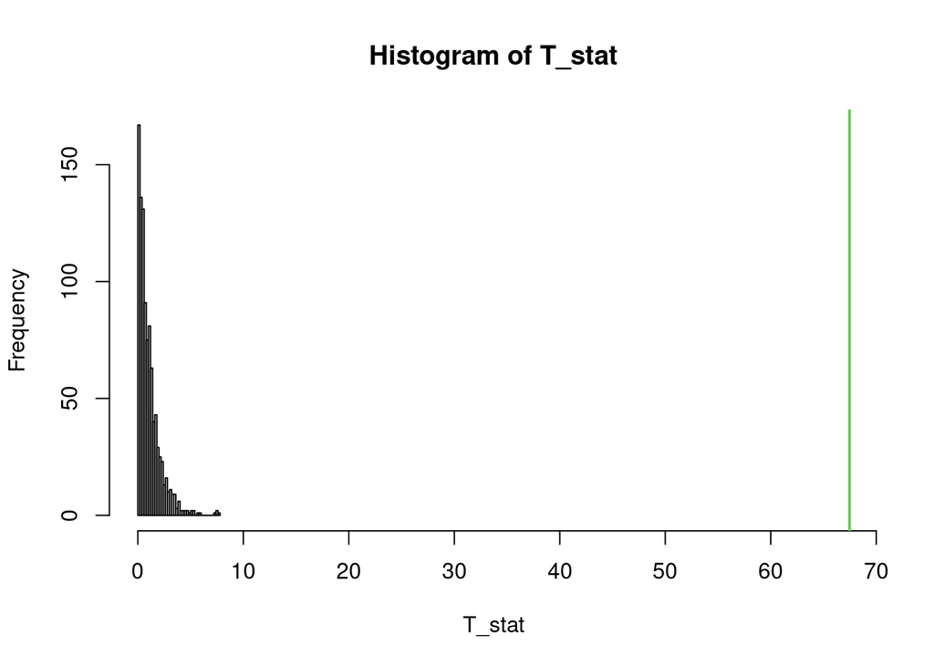

```r
hist(T_stat,xlim=range(c(T_stat,T0)),breaks=30)
abline(v=T0,col=3,lwd=2)
```

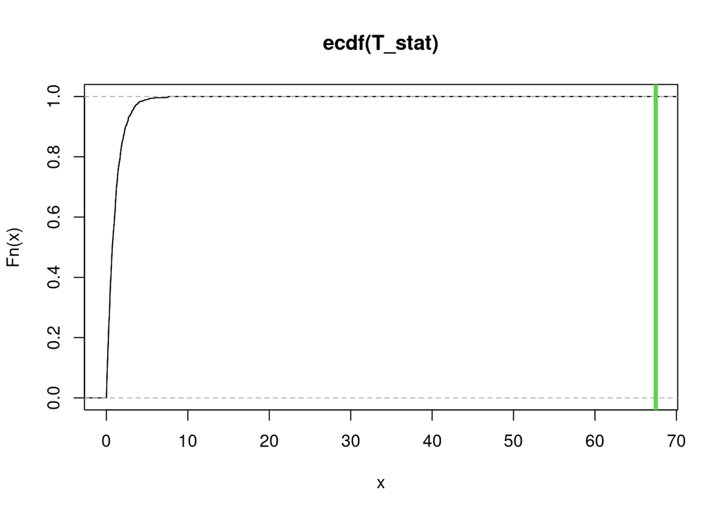

```r
plot(ecdf(T_stat),xlim=range(c(T_stat,T0)))
abline(v=T0,col=3,lwd=4)
```

```r
# p-value
p_val <- sum(T_stat>=T0)/B
p_val
```

```
## [1] 0
```

#### Point 2

To answer to the next point, you need to perform a proper post-hoc test. Let’s go with two permutational t-tests, using as a reference level the third athlete (who seems the best…)

```r
pooled1=chrono[athlete!=2,]
n1=nrow(pooled1)
ath_3=pooled1$athlete==3
T0=abs(mean(pooled1$reaction_time[ath_3])-mean(pooled1$reaction_time[!ath_3]))
T0
```

```
## [1] 0.4339291
```

```r
T_stat=numeric(B)
for(perm in 1:B){
  # permutation:
  permutation <- sample(1:n1)
  time_perm <- pooled1$reaction_time[permutation]
  ref_perm <- time_perm[ath_3]
  other_perm <- time_perm[!ath_3]
  # test statistic:
  T_stat[perm] <- abs(mean(other_perm) - mean(ref_perm))
}

p_val <- sum(T_stat>=T0)/B
p_val
```

```
## [1] 0
```

Athlete 3 is better than Athlete 1

```r
pooled2=chrono[athlete!=1,]
n2=nrow(pooled2)
ath_3=pooled2$athlete==3
T0=abs(mean(pooled2$reaction_time[ath_3])-mean(pooled2$reaction_time[!ath_3]))
T0
```

```
## [1] 0.9567053
```

```r
T_stat=numeric(B)
for(perm in 1:B){
  # permutation:
  permutation <- sample(1:n1)
  time_perm <- pooled1$reaction_time[permutation]
  ref_perm <- time_perm[ath_3]
  other_perm <- time_perm[!ath_3]
  # test statistic:
  T_stat[perm] <- abs(mean(other_perm) - mean(ref_perm))
}

p_val <- sum(T_stat>=T0)/B
p_val
```

```
## [1] 0
```

Athlete 3 is also better than Athlete 2

#### Point 3

We are suggested to use the permutational approach, we could nevertheless use a bootstrap one…

```r
uni_t_perm=function(data,mu0,B=1000){

  data_trans=data-mu0
  T0=abs(mean(data_trans))
  T_perm=numeric(B)
  n=length(data)

  for(perm in 1:B){

    refl <- rbinom(n, 1, 0.5)*2 - 1
    T_perm[perm]=abs(mean(data_trans*refl))

  }
  return(sum(T_perm>=T0)/B)
}

library(pbapply)
library(parallel)


grid=seq(0,2,by=0.001)

cl=makeCluster(2)
ath_3=reaction_time[athlete==3]


clusterExport(cl,varlist=list("ath_3","uni_t_perm"))

mean(ath_3)
```

```
## [1] 1.0602
```

```r
perm_wrapper=function(grid_point){uni_t_perm(ath_3,grid_point)}
pval_function=pbsapply(grid,perm_wrapper)#,cl=cl)

plot(grid,pval_function,type='l')

range(grid[pval_function>0.05])
```

```
## [1] 0.944 1.170
```

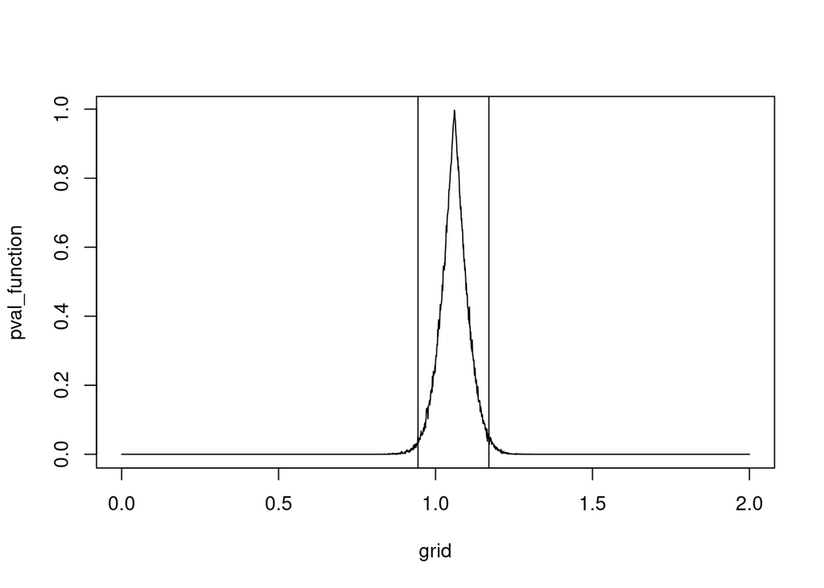

```r
abline(v=range(grid[pval_function>0.05]))
```

And now the bootstrap one

```r
T0=mean(ath_3)
B=1000
T.boot=numeric(B)

for(b in 1:B)
{
  x.b <- sample(ath_3, replace = T)
  T.boot[b] <- mean(x.b)
}

# RP intervals

alpha <- 0.05

right.quantile <- quantile(T.boot, 1 - alpha/2)
left.quantile  <- quantile(T.boot, alpha/2)

T0
```

```
## [1] 1.0602
```

```r
right.quantile - T0
```

```
##     97.5%
## 0.1052227
```

```r
left.quantile  - T0
```

```
##       2.5%
## -0.1109565
```

```r
CI.RP <- c(T0 - (right.quantile - T0), T0 - (left.quantile - T0))
CI.RP
```

```
##     97.5%      2.5%
## 0.9549771 1.1711564
```

```r
range(grid[pval_function>0.05])
```

[output not shown]